# Отчет по предмету Интеллектуальный анализ данных

## Задание 1

*Калганов Максим*

### Алгоритм Partition

#### Описание алгоритма:

Алгоритмами Partition называется множество алгоритмов, задачей которых является кластеризация. Основным алгоритмом Partition является алгоритм k-средних. Остальные алгоритмы являются его расширением.

**Математическое описание алгоритма**:

*Дано*:  
- набор из n наблюдений $X=\{x_1,x_2,...,x_n\},x_i∈R^d, i=1,...,n;$  
- k - требуемое число кластеров, $k∈N, k≤n$.

*Требуется*:  
Разделить множество наблюдений $X$ на $k$ кластеров $S_1,S_2,...,S_k$:

- $S_i∩S_j=∅,i≠j$
- $⋃^k_{i=1}S_i=X$

*Действие алгоритма*:  
Алгоритм k-means разбивает набор $X$ на $k$ наборов $S_1,S_2,...,S_k$, таким образом, чтобы минимизировать сумму квадратов расстояний от каждой точки кластера до его центра (центр масс кластера). Введем обозначение, $S=\{S_1,S_2,...,S_k\}$.  
Тогда действие алгоритма k-means равносильно поиску:

$$argmin_S \sum_{i=1}^k \sum_{{x} \in {S_i}} ρ(x,μ_i)^2, \space (1)$$
где $μ_i$ – центры кластеров, $i=1,...,k$, $ρ(x,μ_i)$ – функция расстояния между $x$ и $μ_i$

*Шаги алгоритма*:

1. Начальный шаг: инициализация кластеров  
   Выбирается произвольное множество точек $μ_i, i=1,...,k$, рассматриваемых как начальные центры кластеров: $μ^{(0)}_i=μ_i$, $i=1,...,k$
2. Распределение векторов по кластерам  
   Шаг $t:∀x_i∈X, i=1,...,n:x_i∈S_j⟺j=argmin_kρ(x_i,μ^{(t−1)}_k)^2$
3. Пересчет центров кластеров  
   Шаг $t:∀i=1,...,k:μ^{(t)}_i=\frac{1}{|S_i|} \sum_{x∈S_i}x$
4. Проверка условия останова: Если $∃i∈1,..,.k:μ^{(t)}_i≠μ^{(t−1)}_i$ тогда
- $t=t+1$;
- перейти на шаг 2; иначе остановится

#### Реализация:

##### **Функционал**

```r
library(ggplot2)

clusterize <- function(matr, clusters){
  diff_c1 <- sweep(matr[, 1:2], 2, clusters[1])
  diff_c2 <- sweep(matr[, 1:2], 2, clusters[2])

  dist_c1 <- rowSums(diff_c1 ^ 2)
  dist_c2 <- rowSums(diff_c2 ^ 2)

  matr[, 3] <- ifelse(dist_c1 < dist_c2, 2, 3)
  return(matr)
}

get_new_clusters <- function(matr){
  cluster1 <- subset(matr, matr[, 3] == 2)
  cluster2 <- subset(matr, matr[, 3] == 3)

  new_cluster1 <- colMeans(cluster1)[1:2]
  new_cluster2 <- colMeans(cluster2)[1:2]

  return(rbind(new_cluster1, new_cluster2))
}

init_clusters <- function(matr){
  centroids_ids = sample(1:80, 2)

  c1 <- data_matrix[centroids_ids[1], 1:2]
  c2 <- data_matrix[centroids_ids[2], 1:2]
  return(rbind(c1, c2))
}
```

##### **Данные**

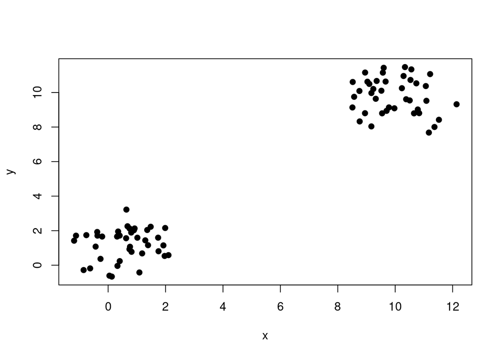

```r
set.seed(10)
data_matrix <- cbind(c(rnorm(40, mean = 1, sd = 1),
                       rnorm(40, mean = 10, sd = 1)),
                     c(rnorm(40, mean = 1, sd = 1),
                       rnorm(40, mean = 10, sd = 1)),
                     rep(1, 80))
colnames(data_matrix) <- c("x", "y", "col")

plot(data_matrix, col=data_matrix[, 3], pch=19)
```

##### **Шаги алгоритма**

Первое приближение:

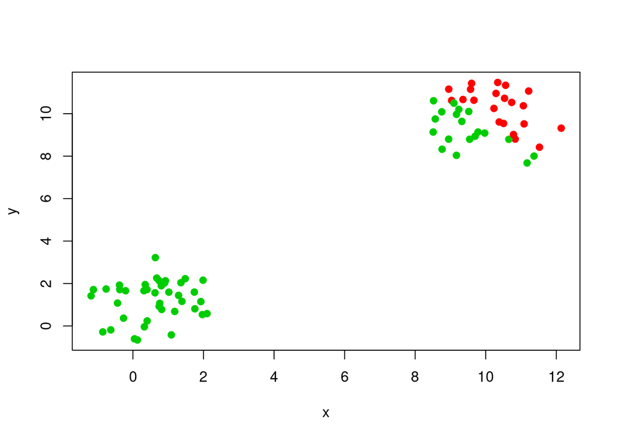

```r
clusters <- init_clusters(data_matrix)
data_matrix <- clusterize(data_matrix, clusters)
new_clusters <- get_new_clusters(data_matrix)
plot(data_matrix, col=data_matrix[, 3], pch=19)
```

После сходимости метода:

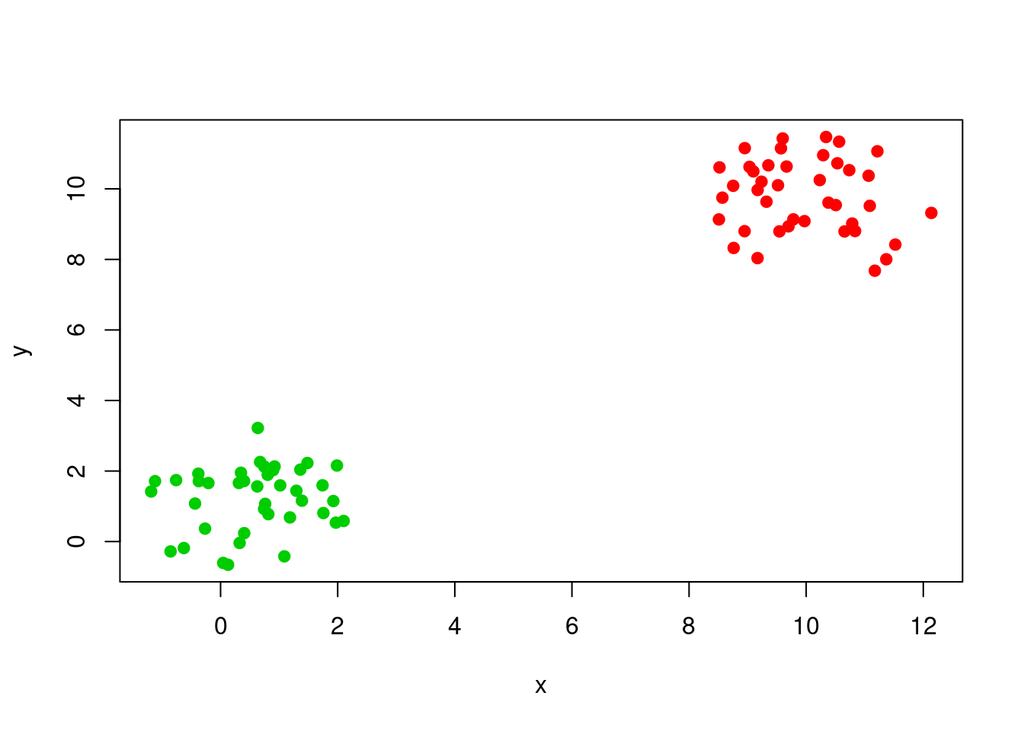

```r
while (any(clusters != new_clusters)){
  clusters = new_clusters
  data_matrix <- clusterize(data_matrix, clusters)
  new_clusters <- get_new_clusters(data_matrix)
}

plot(data_matrix, col=data_matrix[, 3], pch=19)
```

### Алгоритм Apriori

#### Описание алгоритма:

Алгоритм Apriori ищет ассоциативные правила и применяется по отношению к базам данных, содержащим огромное количество транзакций.

#### Шаги

Алгоритм Apriori состоит из трех шагов:

1. Объединение. Просмотр базы данных и определение частоты вхождения отдельных товаров.
2. Отсечение. Те наборы, которые удовлетворяют поддержке и достоверности, переходят на следующую итерацию с двухкомпонентными наборами,
3. Повторение. Предыдущие два шага повторяются для каждой величины набора, пока не будет повторно получен ранее определенный размер.

#### Данные

Для проверки того, что алгоритм работает правильно, данные были взяты из задания 2.1

```
Ф, А, К, У, Л
И, Н, Ф, О, Р, М
К, А, Л, Н, О
М, А, К, И

minsup = 40%
minconf = 40%
```

#### Реализация

```
import sys

from itertools import chain, combinations
from collections import defaultdict
from optparse import OptionParser
from typing import Iterable


def subsets(arr):
    return chain(*[combinations(arr, i + 1) for i, a in enumerate(arr)])


def return_items_with_min_support(item_set, transaction_list, min_support, freq_set):
    _item_set = set()
    local_set = defaultdict(int)
    for item in item_set:
        for transaction in transaction_list:
            if item.issubset(transaction):
                freq_set[item] += 1
                local_set[item] += 1

    for item, count in local_set.items():
        support = float(count) / len(transaction_list)
        if support >= min_support:
            _item_set.add(item)

    return _item_set


def join_set(item_set: Iterable, length: int):
    return set([i.union(j) for i in item_set for j in item_set if len(i.union(j)) == length])


def get_item_set_transaction_list(data_iterator: Iterable):
    transaction_list = list()
    item_set = set()
    for record in data_iterator:
        transaction = frozenset(record)
        transaction_list.append(transaction)
        for item in transaction:
```

[output cut: 35 more lines]

```
                                                                                             freq_set,
                                                                                             transaction_list)
                    if confidence >= min_confidence:
                        to_ret_rules.append(((tuple(element), tuple(remain)),
                                             confidence))
    return to_ret_items, to_ret_rules


def print_results(items, rules):
    for item, support in sorted(items, key=lambda x: x[1]):
        print(f"item - {item}, support - {support}")
    print()
    for rule, confidence in sorted(rules, key=lambda x: x[1]):
        pre, post = rule
        print(f"rule - {pre} -> {post}, confidence - {confidence}")
```

##### Результат работы

```
item - ('Ф',), support - 0.5
item - ('О',), support - 0.5
item - ('Н',), support - 0.5
item - ('Л',), support - 0.5
item - ('И',), support - 0.5
item - ('М',), support - 0.5
item - ('Л', 'К'), support - 0.5
item - ('Л', 'А'), support - 0.5
item - ('Н', 'О'), support - 0.5
item - ('И', 'М'), support - 0.5
item - ('Л', 'А', 'К'), support - 0.5
item - ('А',), support - 0.75
item - ('К',), support - 0.75
item - ('А', 'К'), support - 0.75

rule - ('К',) -> ('Л',), confidence - 0.6666666666666666
rule - ('А',) -> ('Л',), confidence - 0.6666666666666666
rule - ('А',) -> ('Л', 'К'), confidence - 0.6666666666666666
rule - ('К',) -> ('Л', 'А'), confidence - 0.6666666666666666
rule - ('А', 'К') -> ('Л',), confidence - 0.6666666666666666
rule - ('Л',) -> ('К',), confidence - 1.0
rule - ('Л',) -> ('А',), confidence - 1.0
rule - ('А',) -> ('К',), confidence - 1.0
rule - ('К',) -> ('А',), confidence - 1.0
rule - ('Н',) -> ('О',), confidence - 1.0
rule - ('О',) -> ('Н',), confidence - 1.0
rule - ('И',) -> ('М',), confidence - 1.0
rule - ('М',) -> ('И',), confidence - 1.0
rule - ('Л',) -> ('А', 'К'), confidence - 1.0
rule - ('Л', 'А') -> ('К',), confidence - 1.0
rule - ('Л', 'К') -> ('А',), confidence - 1.0
```

## Задание 2

### 1. Apriori

Найти сильные бинарные ассоциативные правила, т.е. правила для которых $sup>=minsup,\ conf>=minconf$

Данные

```
Ф, А, К, У, Л
И, Н, Ф, О, Р, М
К, А, Л, Н, О
М, А, К, И

minsup = 40%
minconf = 40%
```

| F1 | sup | C1 |
| --- | --- | --- |
| Ф | 2/4 | Ф |
| А | 3/4 | А |
| К | 3/4 | К |
| У | 1/4 | – |
| Л | 2/4 | Л |
| И | 2/4 | И |
| Н | 2/4 | Н |
| О | 2/4 | О |
| Р | 1/4 | – |
| М | 2/4 | М |

[output not shown]

| F3 | sup | C3 |
| --- | --- | --- |
| АКЛ | 2/4 | АКЛ |

### 3. LCS

Пусть даны $x=(К,А,Г,Н,О,В)$ и $y=(А,К,С,И,М)$. Вычислить расстояние $D(x,y)$ между последовательностями $x$ и $y$, используя меру LCS (longest common suvsequence).

#### Решение

$|LCS(x,y)|=1$

$$D(x,y) = |x| + |y| - 2|LCS(x,y)| = 6 + 5 - 2*1 = 9$$